# Assignment2

## PROG8245 Assignment 2: (Total Marks 110)

## Start on 14th of October- Due on 1st of November

- TODO: write your name and ID below
- Name: **Khushbu Nileshkumar Lad**
- ID: **9027375**
- Kindly note that this assignment is to be solved by yourself, without the use of AI and chatbots.
- If chatbot usage is detected, the penalty that is discussed in Week 1 slides will apply.
- Each code block will have a Todo comment which explains the functionality, expected input, and expected output of the function.
- There are 10 marks in this assignment for commenting and code readability.

### Part 1: Visualizations (34)

**NOTE:** Each question for plot in the visualization section is expected to be represented in **one** graph, using the library of your choice:

#### **Question 1**

Using the following dataset: https://raw.githubusercontent.com/mwaskom/seaborn-data/master/penguins.csv choose the most convenient graph to show the following: (18 Marks)

**1. The relationship between the penguin's bill length and bill depth for each species.** (5 marks)

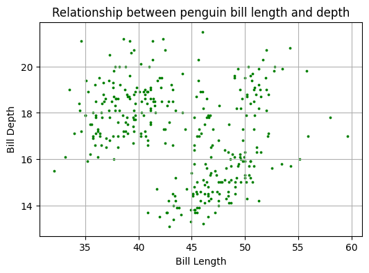

```python
## TODO: Check your attributes, make a graph using Matplotlib or Seaborn to show the relationship needed

# import libraries
import pandas as pd
import matplotlib.pyplot as plt

# Load dataset
Penguins_dataset = pd.read_csv('./Dataset/penguins.csv')

# Ignore null values
Penguins_dataset = Penguins_dataset.dropna()

# Width and depth -> to show dimention, best plot is scatter plot
plt.figure(figsize=(6, 4))
plt.scatter(Penguins_dataset["bill_length_mm"], Penguins_dataset["bill_depth_mm"], color='g',s=3)
plt.title("Relationship between penguin bill length and depth")
plt.xlabel("Bill Length")
plt.ylabel("Bill Depth")
plt.grid(True)
plt.show()
```

**What do you observe from the graph?** (2 marks)

Your answer here:

- The scattered data points demonstrate that penguins have a variety of bill depths and lengths.
- Plotting shows there are very few outliers in the data.
- Most of the penguin bill depth and length are relatively equally distributed, there are very few outliers
- There are 3 visible clusters shows 3 sub population in penguin species bill dimensions.

**Why did you choose this type of graph?** (2 marks)

Your answer here:

- Here we have 2 features "bill length" and "boll depth", both were numeric feature which can be plotted on scatter plot.
- Scatter plot displays individual data point for each record, so it makes easy to understand trends, clusters and outliers from the dataset.

**2. Suitable graph of the mean BMI (BMI not body_mass; BMI Equation is: weight_in_kg/height^2) of female and male penguins. (Assume the height is the flipper length)** (5 marks)

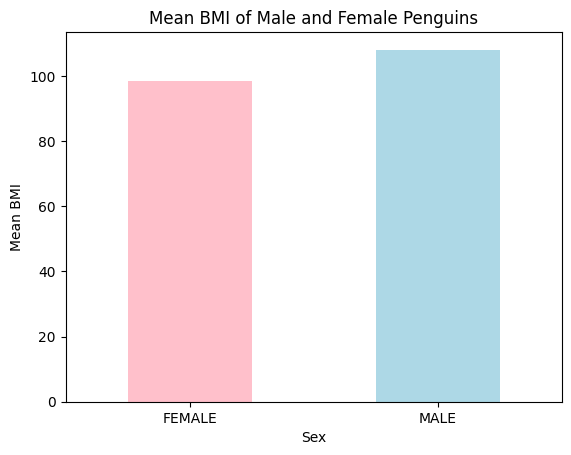

```python
#Your answer here

# Calculate BMI
Penguins_dataset["BMI"] = (Penguins_dataset["body_mass_g"]/1000)/(Penguins_dataset["flipper_length_mm"]/1000)**2
# Penguins_dataset.head(5)

# Find Mean for BMI
mean_bmi = Penguins_dataset.groupby('sex')['BMI'].mean()

# Plot Bar chart for
mean_bmi.plot(kind='bar', color=['pink','lightblue'])
plt.title('Mean BMI of Male and Female Penguins')
plt.xlabel('Sex')
plt.ylabel('Mean BMI')
plt.xticks(rotation=0)
plt.show()
```

**What do you observe from the graph?** (2 marks)

Your answer here:

- Bar chart indicates that the mean BMI for males is higher than females i.e on average male penguins have higher BMI than females.
- Difference between male and female average BMI is relatively small, which shows that both gender have similar body mass index

**Why did you choose this type of graph?** (2 marks)

Your answer here:

- In this case we are **comparing** single numeric value for ***categorical** data.
- Bar chart can show clear comparison between categorical data. Here its male and female.
- Also, It gives details about small differences like here, there is very small difference between male and female BMI but it is clearly visible in graph

#### **Question 2**

You can find the csv file that contains the museum visitors data here: ./CSVs/museum_visitors.csv (8 marks)

Review the data by taking a look at a few of the rows.

```python
# Your solution here
# Load dataset
Museum_dataset = pd.read_csv('./Dataset/museum_visitors.csv')
Museum_dataset.head(10)
```

|  | Date | Avila Adobe | Firehouse Museum | Chinese American Museum | America Tropical Interpretive Center |
| --- | --- | --- | --- | --- | --- |
| 0 | 2014-01-01 | 24778 | 4486 | 1581 | 6602 |
| 1 | 2014-02-01 | 18976 | 4172 | 1785 | 5029 |
| 2 | 2014-03-01 | 25231 | 7082 | 3229 | 8129 |
| 3 | 2014-04-01 | 26989 | 6756 | 2129 | 2824 |
| 4 | 2014-05-01 | 36883 | 10858 | 3676 | 10694 |
| 5 | 2014-06-01 | 29487 | 5751 | 2121 | 11036 |
| 6 | 2014-07-01 | 32378 | 5406 | 2239 | 13490 |
| 7 | 2014-08-01 | 37680 | 8619 | 1769 | 9139 |
| 8 | 2014-09-01 | 28473 | 61192 | 1073 | 5661 |
| 9 | 2014-10-01 | 27995 | 6488 | 1979 | 7356 |

Convince the museum board

The Firehouse Museum claims they ran an event in 2014 that brought an incredible number of visitors, and that they should get extra budget to run a similar event again. The other museums think these types of events aren't that important, and budgets should be split purely based on recent visitors on an average day.

To show the museum board how the event compared to regular traffic at each museum, create a suitable chart that shows how the number of visitors to each museum evolved over time. (4 marks)

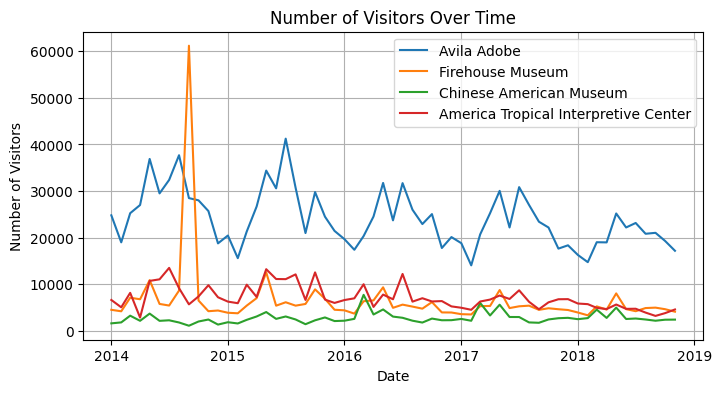

```python
#Your solution here

# Convert date column into python datetime type
Museum_dataset['Date'] = pd.to_datetime(Museum_dataset['Date'])

# Plot line chart for all 4 museums
plt.figure(figsize=(8, 4))
plt.plot(Museum_dataset['Date'], Museum_dataset['Avila Adobe'], label='Avila Adobe')
plt.plot(Museum_dataset['Date'], Museum_dataset['Firehouse Museum'], label='Firehouse Museum')
plt.plot(Museum_dataset['Date'], Museum_dataset['Chinese American Museum'], label='Chinese American Museum')
plt.plot(Museum_dataset['Date'], Museum_dataset['America Tropical Interpretive Center'], label='America Tropical Interpretive Center')

# Adding labels and title
plt.xlabel("Date")
plt.ylabel("Number of Visitors")
plt.title("Number of Visitors Over Time")
plt.legend()
plt.grid(True)
plt.show()
```

What did you observe from the graph? (2 marks)

Your answer here

- The single spike for Firehouse Museum in 2014 is noticeably visible from the graph, which shows that there was higher rush on that event
- The Firehouse Museum's attendance is comparable to or less than that of the other museums during months when there isn't an event of this type. According to this, it does not typically draw significantly more visits than the others under normal circumstances.
- Although the event substantially increased the number of visitors, the Firehouse Museum's regular monthly traffic indicates that, in the absence of a special event, visitor figures are quite comparable to those of the other museums. Given that the impact of the event was transient and unrepresentative of long-term visitor trends, this gives weight to the other museums' argument that the budget should be allocated according to average daily visitors.

Why did you choose this type of graph? (2 marks)

You answer here

- Line chart effectively demonstrates the trends. Here, we have visitors data with the date, to identify trend of number of customer with time line chart can efficiently show it.
- The second requirement here is to compare visitors trend across 4 museums, so line chart is easy to visualize the changes as lines are clearly labeled and have color code with it.

#### **Question 3**

Using the file in ./CSVs/gas_prices.csv  
Use a suitable plot/graph that will show the relationship between the average gas price for each country over all years (vs others). (8 marks)

First, review the data by taking a look at a few of the rows.

```python
# Your solution here
GasPrices_dataset = pd.read_csv('./Dataset/gas_prices.csv')
GasPrices_dataset.head(10)
```

|  | Year | Australia | Canada | France | Germany | Italy | Japan | Mexico | South Korea | UK | USA |
| --- | --- | --- | --- | --- | --- | --- | --- | --- | --- | --- | --- |
| 0 | 1990 | NaN | 1.87 | 3.63 | 2.65 | 4.59 | 3.16 | 1.00 | 2.05 | 2.82 | 1.16 |
| 1 | 1991 | 1.96 | 1.92 | 3.45 | 2.90 | 4.50 | 3.46 | 1.30 | 2.49 | 3.01 | 1.14 |
| 2 | 1992 | 1.89 | 1.73 | 3.56 | 3.27 | 4.53 | 3.58 | 1.50 | 2.65 | 3.06 | 1.13 |
| 3 | 1993 | 1.73 | 1.57 | 3.41 | 3.07 | 3.68 | 4.16 | 1.56 | 2.88 | 2.84 | 1.11 |
| 4 | 1994 | 1.84 | 1.45 | 3.59 | 3.52 | 3.70 | 4.36 | 1.48 | 2.87 | 2.99 | 1.11 |
| 5 | 1995 | 1.95 | 1.53 | 4.26 | 3.96 | 4.00 | 4.43 | 1.11 | 2.94 | 3.21 | 1.15 |
| 6 | 1996 | 2.12 | 1.61 | 4.41 | 3.94 | 4.39 | 3.64 | 1.25 | 3.18 | 3.34 | 1.23 |
| 7 | 1997 | 2.05 | 1.62 | 4.00 | 3.53 | 4.07 | 3.26 | 1.47 | 3.34 | 3.83 | 1.23 |
| 8 | 1998 | 1.63 | 1.38 | 3.87 | 3.34 | 3.84 | 2.82 | 1.49 | 3.04 | 4.06 | 1.06 |
| 9 | 1999 | 1.72 | 1.52 | 3.85 | 3.42 | 3.87 | 3.27 | 1.79 | 3.80 | 4.29 | 1.17 |

Then Plot using the most suitable plot on your opinion (5 marks)

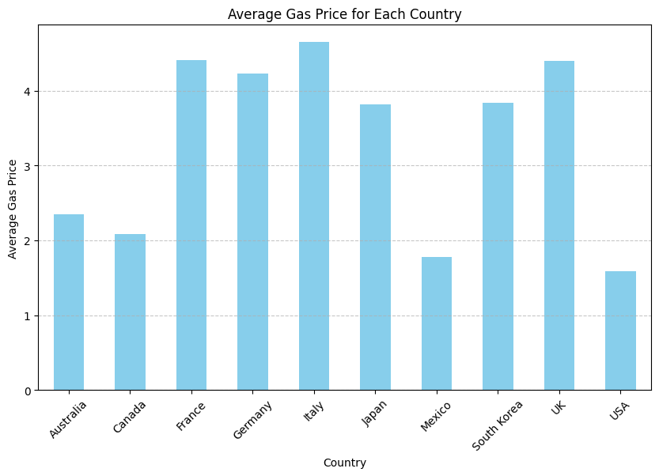

```python
## Your solution here

# Calculate the average gas price for each country over the years
average_prices = GasPrices_dataset.iloc[:, 1:].mean()  # Ignore the 'Year' column as it is not required

# Plot Bar chart
plt.figure(figsize=(10, 6))
average_prices.plot(kind='bar', color='skyblue')

# Add labels and title
plt.xlabel("Country")
plt.ylabel("Average Gas Price")
plt.title("Average Gas Price for Each Country")
plt.xticks(rotation=45)
plt.grid(axis='y', linestyle='--', alpha=0.7)

plt.show()
```

Is there anything interesting observed from the plot/graph? (1 mark)

Your answer here

- The interesting observation here is that USA is having lowest gas prices

Why did you choose this type of graph? (2 marks)

You answer here

- This graph helps see how prices vary across nations by displaying the average price of gas for every country over the specified years.
- Because it makes it easy to compare average petrol prices across nations, a bar chart is a smart option in this case.
- Since each bar represents a country, it is simple to quickly determine whether countries had higher or lower gas prices

### Part 2: Data Tidying and Preprocessing (24)

#### **Question 4:** (12)

**Tuberculosis Dataset** This dataset outlines the number of tuberculosis patients in different countries in the year 2000.  
Dataset name: tb-raw.csv  
A few notes on the raw data set:

- The columns starting with "m" or "f" contain multiple variables:
  - Sex ("m" or "f")
  - Age Group ("0-14","15-24", "25-34", "45-54", "55-64", "65", "unknown")
- Mixture of 0s and missing values("NaN"). This is due to the data collection process and the **distinction** is important for this dataset.
- Task: Apply Data Tidying techniques to get a tidier dataset with more representive columns, please do it step-by-step and explain each step you are doing. (12 Marks)

```python
## TODO: Apply your Data Tidying Technique here

# Load and review data
TB_dataset = pd.read_csv('./Dataset/tb-raw.csv')
TB_dataset.head(30)
```

|  | country | year | m014 | m1524 | m2534 | m3544 | m4554 | m5564 | m65 | mu | f014 |
| --- | --- | --- | --- | --- | --- | --- | --- | --- | --- | --- | --- |
| 0 | AD | 2000 | 0.0 | 0.0 | 1.0 | 0.0 | 0 | 0 | 0.0 | NaN | NaN |
| 1 | AE | 2000 | 2.0 | 4.0 | 4.0 | 6.0 | 5 | 12 | 10.0 | NaN | 3.0 |
| 2 | AF | 2000 | 52.0 | 228.0 | 183.0 | 149.0 | 129 | 94 | 80.0 | NaN | 93.0 |
| 3 | AG | 2000 | 0.0 | 0.0 | 0.0 | 0.0 | 0 | 0 | 1.0 | NaN | 1.0 |
| 4 | AL | 2000 | 2.0 | 19.0 | 21.0 | 14.0 | 24 | 19 | 16.0 | NaN | 3.0 |
| 5 | AM | 2000 | 2.0 | 152.0 | 130.0 | 131.0 | 63 | 26 | 21.0 | NaN | 1.0 |
| 6 | AN | 2000 | 0.0 | 0.0 | 1.0 | 2.0 | 0 | 0 | 0.0 | NaN | 0.0 |
| 7 | AO | 2000 | 186.0 | 999.0 | 1003.0 | 912.0 | 482 | 312 | 194.0 | NaN | 247.0 |
| 8 | AR | 2000 | 97.0 | 278.0 | 594.0 | 402.0 | 419 | 368 | 330.0 | NaN | 121.0 |
| 9 | AS | 2000 | NaN | NaN | NaN | NaN | 1 | 1 | NaN | NaN | NaN |

1. **Column to row transformation** :
- Data contains patient count for country, year, gender and age group, so first it needs to be converted into columns
- Columns will be country, year, (Gender + Age group - separate it in next step) and patient count

```python
TB_dataset_clean = TB_dataset.melt(id_vars=["country", "year"],
                    value_vars=[col for col in TB_dataset.columns if col not in ["country", "year"]],
                    var_name="GenderAndAgeGroup",
                    value_name="PatientCount")

TB_dataset_clean.head(10)
```

|  | country | year | GenderAndAgeGroup | PatientCount |
| --- | --- | --- | --- | --- |
| 0 | AD | 2000 | m014 | 0.0 |
| 1 | AE | 2000 | m014 | 2.0 |
| 2 | AF | 2000 | m014 | 52.0 |
| 3 | AG | 2000 | m014 | 0.0 |
| 4 | AL | 2000 | m014 | 2.0 |
| 5 | AM | 2000 | m014 | 2.0 |
| 6 | AN | 2000 | m014 | 0.0 |
| 7 | AO | 2000 | m014 | 186.0 |
| 8 | AR | 2000 | m014 | 97.0 |
| 9 | AS | 2000 | m014 | NaN |

2. **Separate column for Gender and Age Group from single column**

```python
# Extract "Sex" and "Age Group" from the "GenderAndAgeGroup" column
TB_dataset_clean['Gender'] = TB_dataset_clean['GenderAndAgeGroup'].str[0]  # 'm' or 'f'
TB_dataset_clean['Age Group'] = TB_dataset_clean['GenderAndAgeGroup'].str[1:]  # age range

# Remove Combined column
TB_dataset_clean = TB_dataset_clean.drop(columns=["GenderAndAgeGroup"])

TB_dataset_clean.head(10)
```

|  | country | year | PatientCount | Gender | Age Group |
| --- | --- | --- | --- | --- | --- |
| 0 | AD | 2000 | 0.0 | m | 014 |
| 1 | AE | 2000 | 2.0 | m | 014 |
| 2 | AF | 2000 | 52.0 | m | 014 |
| 3 | AG | 2000 | 0.0 | m | 014 |
| 4 | AL | 2000 | 2.0 | m | 014 |
| 5 | AM | 2000 | 2.0 | m | 014 |
| 6 | AN | 2000 | 0.0 | m | 014 |
| 7 | AO | 2000 | 186.0 | m | 014 |
| 8 | AR | 2000 | 97.0 | m | 014 |
| 9 | AS | 2000 | NaN | m | 014 |

3. **Simplify Age Group titles for better understanding**

```python
# Create mapping for all possible values
age_group_mapping = {
    "014": "0-14",
    "1524": "15-24",
    "2534": "25-34",
    "3544": "35-44",
    "4554": "45-54",
    "5564": "55-64",
    "65": "65+",
    "u": "unknown"
}

# Apply the mapping to the Age Group column
TB_dataset_clean['Age Group'] = TB_dataset_clean['Age Group'].map(age_group_mapping)

# Review change
TB_dataset_clean.head(10)
```

|  | country | year | PatientCount | Gender | Age Group |
| --- | --- | --- | --- | --- | --- |
| 0 | AD | 2000 | 0.0 | m | 0-14 |
| 1 | AE | 2000 | 2.0 | m | 0-14 |
| 2 | AF | 2000 | 52.0 | m | 0-14 |
| 3 | AG | 2000 | 0.0 | m | 0-14 |
| 4 | AL | 2000 | 2.0 | m | 0-14 |
| 5 | AM | 2000 | 2.0 | m | 0-14 |
| 6 | AN | 2000 | 0.0 | m | 0-14 |
| 7 | AO | 2000 | 186.0 | m | 0-14 |
| 8 | AR | 2000 | 97.0 | m | 0-14 |
| 9 | AS | 2000 | NaN | m | 0-14 |

4. **Replace NaN with Panda's NA as per instruction**

```python
TB_dataset_clean['count'] = TB_dataset_clean['PatientCount'].replace("NaN", pd.NA)
TB_dataset_clean.head(50)
```

|  | country | year | PatientCount | Gender | Age Group | count |
| --- | --- | --- | --- | --- | --- | --- |
| 0 | AD | 2000 | 0.0 | m | 0-14 | 0.0 |
| 1 | AE | 2000 | 2.0 | m | 0-14 | 2.0 |
| 2 | AF | 2000 | 52.0 | m | 0-14 | 52.0 |
| 3 | AG | 2000 | 0.0 | m | 0-14 | 0.0 |
| 4 | AL | 2000 | 2.0 | m | 0-14 | 2.0 |
| 5 | AM | 2000 | 2.0 | m | 0-14 | 2.0 |
| 6 | AN | 2000 | 0.0 | m | 0-14 | 0.0 |
| 7 | AO | 2000 | 186.0 | m | 0-14 | 186.0 |
| 8 | AR | 2000 | 97.0 | m | 0-14 | 97.0 |
| 9 | AS | 2000 | NaN | m | 0-14 | NaN |
| 10 | AD | 2000 | 0.0 | m | 15-24 | 0.0 |
| 11 | AE | 2000 | 4.0 | m | 15-24 | 4.0 |
| 12 | AF | 2000 | 228.0 | m | 15-24 | 228.0 |
| 13 | AG | 2000 | 0.0 | m | 15-24 | 0.0 |
| 14 | AL | 2000 | 19.0 | m | 15-24 | 19.0 |
| 15 | AM | 2000 | 152.0 | m | 15-24 | 152.0 |
| 16 | AN | 2000 | 0.0 | m | 15-24 | 0.0 |
| 17 | AO | 2000 | 999.0 | m | 15-24 | 999.0 |
| 18 | AR | 2000 | 278.0 | m | 15-24 | 278.0 |
| 19 | AS | 2000 | NaN | m | 15-24 | NaN |
| 20 | AD | 2000 | 1.0 | m | 25-34 | 1.0 |
| 21 | AE | 2000 | 4.0 | m | 25-34 | 4.0 |
| 22 | AF | 2000 | 183.0 | m | 25-34 | 183.0 |
| 23 | AG | 2000 | 0.0 | m | 25-34 | 0.0 |
| 24 | AL | 2000 | 21.0 | m | 25-34 | 21.0 |
| 25 | AM | 2000 | 130.0 | m | 25-34 | 130.0 |
| 26 | AN | 2000 | 1.0 | m | 25-34 | 1.0 |
| 27 | AO | 2000 | 1003.0 | m | 25-34 | 1003.0 |
| 28 | AR | 2000 | 594.0 | m | 25-34 | 594.0 |
| 29 | AS | 2000 | NaN | m | 25-34 | NaN |
| 30 | AD | 2000 | 0.0 | m | 35-44 | 0.0 |
| 31 | AE | 2000 | 6.0 | m | 35-44 | 6.0 |
| 32 | AF | 2000 | 149.0 | m | 35-44 | 149.0 |
| 33 | AG | 2000 | 0.0 | m | 35-44 | 0.0 |
| 34 | AL | 2000 | 14.0 | m | 35-44 | 14.0 |
| 35 | AM | 2000 | 131.0 | m | 35-44 | 131.0 |
| 36 | AN | 2000 | 2.0 | m | 35-44 | 2.0 |
| 37 | AO | 2000 | 912.0 | m | 35-44 | 912.0 |
| 38 | AR | 2000 | 402.0 | m | 35-44 | 402.0 |
| 39 | AS | 2000 | NaN | m | 35-44 | NaN |
| 40 | AD | 2000 | 0.0 | m | 45-54 | 0.0 |
| 41 | AE | 2000 | 5.0 | m | 45-54 | 5.0 |
| 42 | AF | 2000 | 129.0 | m | 45-54 | 129.0 |
| 43 | AG | 2000 | 0.0 | m | 45-54 | 0.0 |
| 44 | AL | 2000 | 24.0 | m | 45-54 | 24.0 |
| 45 | AM | 2000 | 63.0 | m | 45-54 | 63.0 |
| 46 | AN | 2000 | 0.0 | m | 45-54 | 0.0 |
| 47 | AO | 2000 | 482.0 | m | 45-54 | 482.0 |
| 48 | AR | 2000 | 419.0 | m | 45-54 | 419.0 |
| 49 | AS | 2000 | 1.0 | m | 45-54 | 1.0 |

#### Question 5: (12)

Using Boston House pricing dataset, apply outlier detection techniques discussed in class to detect outliers. Use different techniques and comment your code.  
You need to check how to load the dataset correctly!

1. You should include some Visualization techniques
2. You should include some statistical approaches
3. You should analyze your attributes using **Univariant and multivariant** outlier detection techniques.
4. Choose one or more of your outlier detection techniques and remove outliers

```python
# Importing
data_url = "http://lib.stat.cmu.edu/datasets/boston"
# Downloaded txt file and converted in csv
Boston_dataset = pd.read_csv("./Dataset/boston.csv")

# Convert columns to numeric
columns_to_convert = ["CRIM", "ZN", "INDUS", "CHAS", "NOX", "RM", "AGE", "DIS", "RAD", "TAX", "PTRATIO", "B", "LSTAT", "MEDV"]
for column in columns_to_convert:
    Boston_dataset[column] = pd.to_numeric(Boston_dataset[column], errors='coerce')

# Fill mean in place of null
Boston_dataset.fillna(Boston_dataset.mean(), inplace=True)
# Remove NaN Values
Boston_dataset.dropna(inplace=True)

# Display the first 20 rows of the dataset
Boston_dataset.head(20)
```

|  | CRIM | ZN | INDUS | CHAS | NOX | RM | AGE | DIS | RAD | TAX | PTRATIO | B | LSTAT | MEDV |
| --- | --- | --- | --- | --- | --- | --- | --- | --- | --- | --- | --- | --- | --- | --- |
| 0 | 0.00632 | 18.0 | 2.31 | 0 | 0.538 | 6.575 | 65.2 | 4.0900 | 1 | 296 | 15.3 | 396.90 | 4.98 | 24.0 |
| 1 | 0.02731 | 0.0 | 7.07 | 0 | 0.469 | 6.421 | 78.9 | 4.9671 | 2 | 242 | 17.8 | 396.90 | 9.14 | 21.6 |
| 2 | 0.02729 | 0.0 | 7.07 | 0 | 0.469 | 7.185 | 61.1 | 4.9671 | 2 | 242 | 17.8 | 392.83 | 4.03 | 34.7 |
| 3 | 0.03237 | 0.0 | 2.18 | 0 | 0.458 | 6.998 | 45.8 | 6.0622 | 3 | 222 | 18.7 | 394.63 | 2.94 | 33.4 |
| 4 | 0.06905 | 0.0 | 2.18 | 0 | 0.458 | 7.147 | 54.2 | 6.0622 | 3 | 222 | 18.7 | 396.90 | 5.33 | 36.2 |
| 5 | 0.02985 | 0.0 | 2.18 | 0 | 0.458 | 6.430 | 58.7 | 6.0622 | 3 | 222 | 18.7 | 394.12 | 5.21 | 28.7 |
| 6 | 0.08829 | 12.5 | 7.87 | 0 | 0.524 | 6.012 | 66.6 | 5.5605 | 5 | 311 | 15.2 | 395.60 | 12.43 | 22.9 |
| 7 | 0.14455 | 12.5 | 7.87 | 0 | 0.524 | 6.172 | 96.1 | 5.9505 | 5 | 311 | 15.2 | 396.90 | 19.15 | 27.1 |
| 8 | 0.21124 | 12.5 | 7.87 | 0 | 0.524 | 5.631 | 100.0 | 6.0821 | 5 | 311 | 15.2 | 386.63 | 29.93 | 16.5 |
| 9 | 0.17004 | 12.5 | 7.87 | 0 | 0.524 | 6.004 | 85.9 | 6.5921 | 5 | 311 | 15.2 | 386.71 | 17.10 | 18.9 |
| 10 | 0.22489 | 12.5 | 7.87 | 0 | 0.524 | 6.377 | 94.3 | 6.3467 | 5 | 311 | 15.2 | 392.52 | 20.45 | 15.0 |
| 11 | 0.11747 | 12.5 | 7.87 | 0 | 0.524 | 6.009 | 82.9 | 6.2267 | 5 | 311 | 15.2 | 396.90 | 13.27 | 18.9 |
| 12 | 0.09378 | 12.5 | 7.87 | 0 | 0.524 | 5.889 | 39.0 | 5.4509 | 5 | 311 | 15.2 | 390.50 | 15.71 | 21.7 |
| 13 | 0.62976 | 0.0 | 8.14 | 0 | 0.538 | 5.949 | 61.8 | 4.7075 | 4 | 307 | 21.0 | 396.90 | 8.26 | 20.4 |
| 14 | 0.63796 | 0.0 | 8.14 | 0 | 0.538 | 6.096 | 84.5 | 4.4619 | 4 | 307 | 21.0 | 380.02 | 10.26 | 18.2 |
| 15 | 0.62739 | 0.0 | 8.14 | 0 | 0.538 | 5.834 | 56.5 | 4.4986 | 4 | 307 | 21.0 | 395.62 | 8.47 | 19.9 |
| 16 | 1.05393 | 0.0 | 8.14 | 0 | 0.538 | 5.935 | 29.3 | 4.4986 | 4 | 307 | 21.0 | 386.85 | 6.58 | 23.1 |
| 17 | 0.78420 | 0.0 | 8.14 | 0 | 0.538 | 5.990 | 81.7 | 4.2579 | 4 | 307 | 21.0 | 386.75 | 14.67 | 17.5 |
| 18 | 0.80271 | 0.0 | 8.14 | 0 | 0.538 | 5.456 | 36.6 | 3.7965 | 4 | 307 | 21.0 | 288.99 | 11.69 | 20.2 |
| 19 | 0.72580 | 0.0 | 8.14 | 0 | 0.538 | 5.727 | 69.5 | 3.7965 | 4 | 307 | 21.0 | 390.95 | 11.28 | 18.2 |

Data Visualization : Box plot for all numeric columns

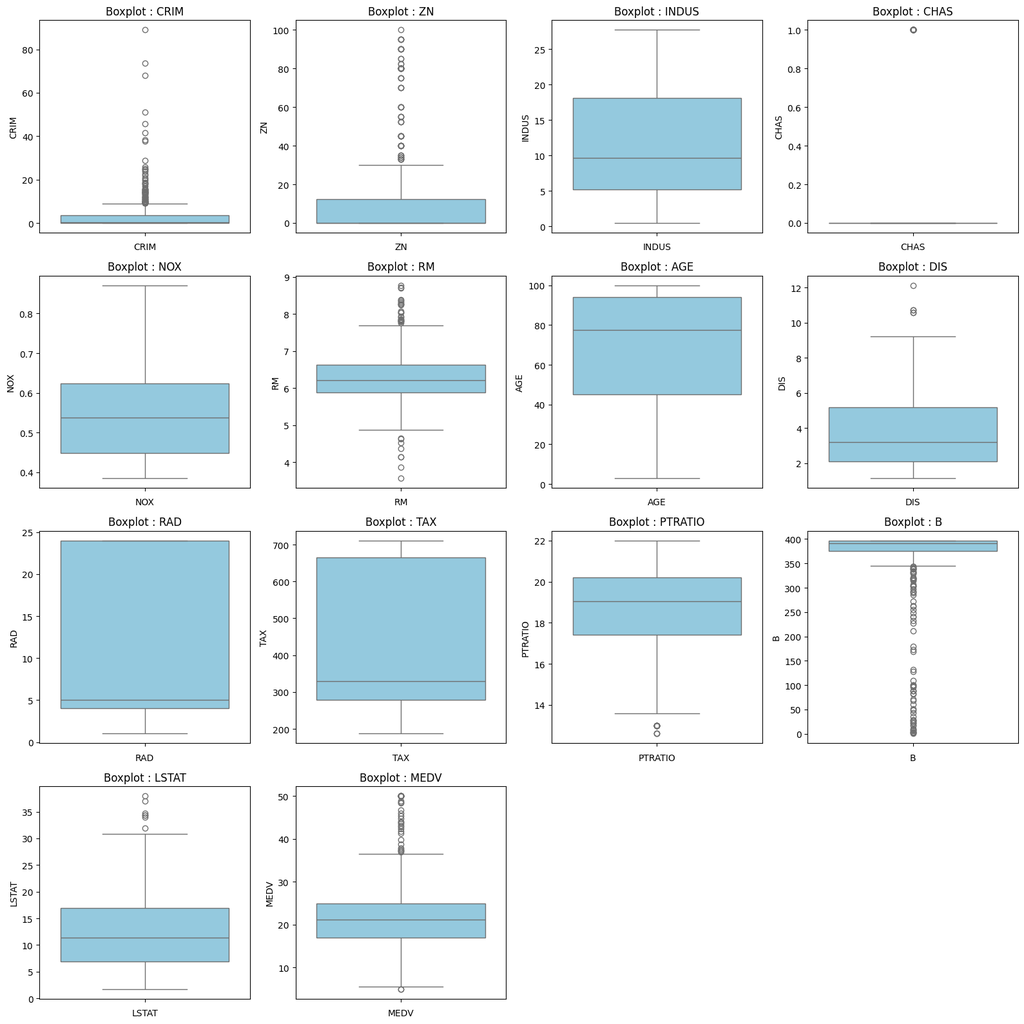

```python
import matplotlib.pyplot as plt
import seaborn as sns

# Setup the subplots with 4x4 grid and larger figure size
fig, axes = plt.subplots(nrows=4, ncols=4, figsize=(16, 16))
axes = axes.flatten()

# Get only numeric columns
numeric_columns = Boston_dataset.select_dtypes(include=['number']).columns

# Plot both boxplot and density plot for each numeric column
for i, column in enumerate(numeric_columns):
    # Plot boxplot
    sns.boxplot(y=Boston_dataset[column], ax=axes[i], color='skyblue')
    axes[i].set_title(f'Boxplot : {column}')
    axes[i].set_xlabel(column)

# Hide unused axes
for i in range(len(numeric_columns), len(axes)):
    axes[i].set_visible(False)

plt.tight_layout()
plt.show()
```

##### Statistical Approaches for Outlier Detection : Z-Score Method

```python
import numpy as np
from scipy import stats

# Calculate Z-scores
z_scores = stats.zscore(Boston_dataset)
abs_z_scores = np.abs(z_scores)
threshold = 3
Outliers_ZScore = (abs_z_scores > threshold)

# Identify outliers
Outliers_ZScore_indices = np.where(Outliers_ZScore)
print("Z-Score Outliers Indices:", Outliers_ZScore_indices)
```

```
Z-Score Outliers Indices: (array([ 55,  56,  57, 102, 141, 142, 152, 154, 155, 160, 162, 163, 199,
       200, 201, 202, 203, 204, 208, 209, 210, 211, 212, 216, 218, 219,
       220, 221, 222, 225, 234, 236, 256, 257, 262, 269, 273, 274, 276,
       277, 282, 283, 283, 284, 347, 351, 352, 353, 353, 354, 355, 356,
       357, 358, 363, 364, 364, 365, 367, 369, 370, 372, 373, 374, 374,
       380, 398, 404, 405, 406, 410, 410, 411, 412, 412, 414, 414, 415,
       416, 418, 418, 419, 423, 424, 425, 426, 427, 427, 429, 431, 436,
       437, 438, 445, 450, 454, 455, 456, 457, 466]), array([ 1,  1,  1, 11, 12,  3,  3,  3,  3,  3,  3,  3,  1,  1,  1,  1,  1,
        1,  3,  3,  3,  3,  3,  3,  3,  3,  3,  3,  3,  5,  3,  3,  1,  5,
        5,  3,  3,  3,  3,  3,  3,  1,  3,  1,  1,  7,  7,  1,  7,  7,  7,
        3,  3,  3,  3,  3,  5,  5,  5,  3,  3,  3, 12,  5, 12,  0,  0,  0,
        0,  5,  0, 11, 11, 11, 12,  0, 12, 11, 11,  0, 11, 11, 11, 11, 11,
       11,  0, 11, 11, 11, 11, 11, 11, 11, 11, 11, 11, 11, 11, 11]))
```

##### Statistical Approaches for Outlier Detection : IQR Method

```python
Q1 = Boston_dataset.quantile(0.25)
Q3 = Boston_dataset.quantile(0.75)
IQR = Q3 - Q1

outliers_iqr = ((Boston_dataset < (Q1 - 1.5 * IQR)) | (Boston_dataset > (Q3 + 1.5 * IQR)))

outliers_iqr_indices = outliers_iqr.any(axis=1)
print("IQR Outliers Indices:", Boston_dataset[outliers_iqr_indices])
```

```
IQR Outliers Indices:          CRIM   ZN  INDUS  CHAS    NOX     RM   AGE     DIS  RAD  TAX  \
18    0.80271  0.0   8.14     0  0.538  5.456  36.6  3.7965    4  307
25    0.84054  0.0   8.14     0  0.538  5.599  85.7  4.4546    4  307
27    0.95577  0.0   8.14     0  0.538  6.047  88.8  4.4534    4  307
32    1.38799  0.0   8.14     0  0.538  5.950  82.0  3.9900    4  307
34    1.61282  0.0   8.14     0  0.538  6.096  96.9  3.7598    4  307
..        ...  ...    ...   ...    ...    ...   ...     ...  ...  ...
477  15.02340  0.0  18.10     0  0.614  5.304  97.3  2.1007   24  666
478  10.23300  0.0  18.10     0  0.614  6.185  96.7  2.1705   24  666
479  14.33370  0.0  18.10     0  0.614  6.229  88.0  1.9512   24  666
489   0.18337  0.0  27.74     0  0.609  5.414  98.3  1.7554    4  711
490   0.20746  0.0  27.74     0  0.609  5.093  98.0  1.8226    4  711

     PTRATIO       B  LSTAT  MEDV
18      21.0  288.99  11.69  20.2
25      21.0  303.42  16.51  13.9
27      21.0  306.38  17.28  14.8
32      21.0  232.60  27.71  13.2
34      21.0  248.31  20.34  13.5
..       ...     ...    ...   ...
477     20.2  349.48  24.91  12.0
478     20.2  379.70  18.03  14.6
479     20.2  383.32  13.11  21.4
489     20.1  344.05  23.97   7.0
490     20.1  318.43  29.68   8.1

[238 rows x 14 columns]
```

##### Multivariate Outlier Detection

```python
import numpy as np
from scipy.spatial import distance

# Calculate Mahalanobis distance

# Covariance matrix of the dataset
cov_matrix = np.cov(Boston_dataset.T)
# Inverse covariance matrix
inv_cov_matrix = np.linalg.inv(cov_matrix)
# Mean of the dataset
mean = Boston_dataset.mean(axis=0)
m_dists = np.array([distance.mahalanobis(x, mean, inv_cov_matrix) for x in Boston_dataset.values])

# Set a threshold for detection
threshold_mahalanobis = 3  # This can be adjusted based on your specific use case

# Identify multivariate outliers
outliers_mahalanobis = np.where(m_dists > threshold_mahalanobis)[0]
print("Mahalanobis Outliers Indices:", outliers_mahalanobis)
```

```
Mahalanobis Outliers Indices: [  0   4   7   8   9  10  11  16  18  32  34  39  40  41  42  43  47  48
  54  55  56  57  60  61  62  63  64  65  66  70  72  73  74  88  92  93
  94  97  98 102 105 106 120 121 122 123 124 125 126 127 128 129 130 131
 132 133 134 135 136 137 138 139 140 141 142 143 144 145 146 147 148 149
 150 151 152 153 154 155 156 157 158 159 160 161 162 163 164 165 166 167
 168 169 170 171 172 180 181 182 183 184 186 187 188 189 190 195 196 197
 198 199 200 201 202 203 204 208 209 210 211 212 214 216 218 219 220 221
 222 224 225 226 228 229 232 233 234 236 244 245 247 252 253 254 255 256
 257 258 259 260 261 262 263 264 265 266 267 268 269 273 274 276 277 280
 282 283 284 286 290 291 292 293 294 295 296 297 298 299 300 304 305 306
 307 310 325 328 329 330 333 334 335 342 345 346 347 348 349 350 351 352
 353 354 355 356 357 358 359 360 361 362 363 364 365 366 367 368 369 370
 371 372 373 374 375 376 377 378 380 381 384 385 386 387 388 398 399 400
 401 403 404 405 406 407 408 409 410 411 412 413 414 415 416 417 418 419
 423 424 425 426 427 428 429 430 431 432 433 434 435 436 437 438 440 445
 450 453 454 455 456 457 463 465 466 471 473 475 480 481 482 483 484 485
 487 488 489 490 491 492 494 495 503 504 505]
```

##### Remove Outliers : Using z-score

```python
# Remove outlier
data_cleaned = Boston_dataset[~Outliers_ZScore]

# Show clean data
data_cleaned.head(10)
```

|  | CRIM | ZN | INDUS | CHAS | NOX | RM | AGE | DIS | RAD | TAX | PTRATIO | B | LSTAT | MEDV |
| --- | --- | --- | --- | --- | --- | --- | --- | --- | --- | --- | --- | --- | --- | --- |
| 0 | 0.00632 | 18.0 | 2.31 | 0.0 | 0.538 | 6.575 | 65.2 | 4.0900 | 1 | 296 | 15.3 | 396.90 | 4.98 | 24.0 |
| 1 | 0.02731 | 0.0 | 7.07 | 0.0 | 0.469 | 6.421 | 78.9 | 4.9671 | 2 | 242 | 17.8 | 396.90 | 9.14 | 21.6 |
| 2 | 0.02729 | 0.0 | 7.07 | 0.0 | 0.469 | 7.185 | 61.1 | 4.9671 | 2 | 242 | 17.8 | 392.83 | 4.03 | 34.7 |
| 3 | 0.03237 | 0.0 | 2.18 | 0.0 | 0.458 | 6.998 | 45.8 | 6.0622 | 3 | 222 | 18.7 | 394.63 | 2.94 | 33.4 |
| 4 | 0.06905 | 0.0 | 2.18 | 0.0 | 0.458 | 7.147 | 54.2 | 6.0622 | 3 | 222 | 18.7 | 396.90 | 5.33 | 36.2 |
| 5 | 0.02985 | 0.0 | 2.18 | 0.0 | 0.458 | 6.430 | 58.7 | 6.0622 | 3 | 222 | 18.7 | 394.12 | 5.21 | 28.7 |
| 6 | 0.08829 | 12.5 | 7.87 | 0.0 | 0.524 | 6.012 | 66.6 | 5.5605 | 5 | 311 | 15.2 | 395.60 | 12.43 | 22.9 |
| 7 | 0.14455 | 12.5 | 7.87 | 0.0 | 0.524 | 6.172 | 96.1 | 5.9505 | 5 | 311 | 15.2 | 396.90 | 19.15 | 27.1 |
| 8 | 0.21124 | 12.5 | 7.87 | 0.0 | 0.524 | 5.631 | 100.0 | 6.0821 | 5 | 311 | 15.2 | 386.63 | 29.93 | 16.5 |
| 9 | 0.17004 | 12.5 | 7.87 | 0.0 | 0.524 | 6.004 | 85.9 | 6.5921 | 5 | 311 | 15.2 | 386.71 | 17.10 | 18.9 |

### Part 3: Feature Engineering (17)

#### Question 6- Feature Engineering - Attribute Correlation (17)

- Load the file income_data.csv, inspect the columns.
- Determine if race and education features have a statistical relationship.
- Explain and conclude your findings (7 till here)
- Inspect the dataset carefully and create an Indicator Feature (0/1) --(3)
- Inspect the dataset carefully and create an Interaction Feature (Additional feature engineered from your dataset)-- (3)  
  **The features you create must be resonable, please add an explanation to explain why did you chose those features** (2 for each explanation -> 4)

```python
## TODO: Start Question 6 code here
Income_Dataset = pd.read_csv("./Dataset/income_data.csv")
Income_Dataset.head(5)
```

|  | age | workclass | fnlwgt | education | educational-num | marital-status | occupation | relationship | race | gender | capital-gain | capital-loss | hours-per-week | native-country | income |
| --- | --- | --- | --- | --- | --- | --- | --- | --- | --- | --- | --- | --- | --- | --- | --- |
| 0 | 25 | Private | 226802 | 11th | 7 | Never-married | Machine-op-inspct | Own-child | Black | Male | 0 | 0 | 40 | United-States | <=50K |
| 1 | 38 | Private | 89814 | HS-grad | 9 | Married-civ-spouse | Farming-fishing | Husband | White | Male | 0 | 0 | 50 | United-States | <=50K |
| 2 | 28 | Local-gov | 336951 | Assoc-acdm | 12 | Married-civ-spouse | Protective-serv | Husband | White | Male | 0 | 0 | 40 | United-States | >50K |
| 3 | 44 | Private | 160323 | Some-college | 10 | Married-civ-spouse | Machine-op-inspct | Husband | Black | Male | 7688 | 0 | 40 | United-States | >50K |
| 4 | 18 | ? | 103497 | Some-college | 10 | Never-married | ? | Own-child | White | Female | 0 | 0 | 30 | United-States | <=50K |

##### Statistical relationship between Race and Education

```python
from scipy.stats import chi2_contingency
contingency_table = pd.crosstab(Income_Dataset['race'], Income_Dataset['education'])
chi2, p, dof, expected = chi2_contingency(contingency_table)
print("Chi2 Stat:", chi2)
print("P-value:", p)
print("Degrees of Freedom:", dof)
print("Expected Frequencies:\n", expected)

alpha = 0.05
if p < alpha:
    print("There is a significant relationship between race and education.")
else:
    print("There is no significant relationship between race and education.")
```

```
Chi2 Stat: 1040.6622432490267
P-value: 7.472985630264855e-179
Degrees of Freedom: 60
Expected Frequencies:
 [[1.33661603e+01 1.74366324e+01 6.32222268e+00 2.37684779e+00
  4.89803857e+00 9.18983662e+00 7.27488637e+00 1.54062078e+01
  1.98327259e+01 7.72234962e+01 5.71598215e+00 1.51887310e+02
  2.55679538e+01 7.98697842e-01 8.02546988e+00 1.04677532e+02]
 [4.31982925e+01 5.63537120e+01 2.04328856e+01 7.68176979e+00
  1.58300438e+01 2.97007698e+01 2.35118136e+01 4.97915524e+01
  6.40976823e+01 2.49579767e+02 1.84735678e+01 4.90886860e+02
  8.26334507e+01 2.58132345e+00 2.59376356e+01 3.38308874e+02]
 [1.33235023e+02 1.73809836e+02 6.30204537e+01 2.36926211e+01
  4.88240654e+01 9.16050735e+01 7.25166865e+01 1.53570390e+02
  1.97694300e+02 7.69770382e+02 5.69773965e+01 1.51402563e+03
  2.54863540e+02 7.96148806e+00 7.99985668e+01 1.04343454e+03]
 [1.15460874e+01 1.50622825e+01 5.46132427e+00 2.05319192e+00
  4.23107162e+00 7.93845461e+00 6.28426354e+00 1.33083412e+01
  1.71320994e+01 6.67079563e+01 4.93763564e+00 1.31204783e+02
  2.20863601e+01 6.89938987e-01 6.93263994e+00 9.04235699e+01]
 [1.18765444e+03 1.54933754e+03 5.61763114e+02 2.11195569e+02
  4.35216781e+02 8.16565865e+02 6.46412350e+02 1.36892351e+03
  1.76224319e+03 6.86171840e+03 5.07895418e+02 1.34959954e+04
  2.27184870e+03 7.09685517e+01 7.13105688e+02 9.30115548e+03]]
There is a significant relationship between race and education.
```

##### Indicator Feature

- Create indicator for education i.e 1 for higher education and 0 for lower.
- Consider Bachelors, Masters and Doctorate as higher education

```python
# Check available data
# Income_Dataset['education'].unique()

Higher_education_levels = ['Bachelors', 'Masters', 'Doctorate']
Income_Dataset['is_high_education'] = Income_Dataset['education'].apply(lambda x: 1 if x in Higher_education_levels else 0)
```

Higher education is important to socioeconomic status assessments because it can have a big impact on earnings and employment prospects.

##### Interaction feature

A comprehensive review of the effects of various combinations of ethnic backgrounds and educational attainment on outcomes such as occupation and income is made possible by this feature. Examining this relationship allows us to determine whether some ethnic groups earn more from particular educational attainment than others, which is important information for understanding socioeconomic gaps and developing policy.

```python
Income_Dataset['education_race_interaction'] = Income_Dataset['education'] + "_" + Income_Dataset['race']
```

One way to see how race and education together affect income is to develop an interaction feature called education_race_interaction.

### Part 4: Challenging Preprocessing Problems

#### Question 7: Implementing the Local Outlier Factor (LOF) Function (25)

- Local outlier factor is a function that labels outlier based on 2 predefined parameters, the first one is t **k** for k-Nearest-Neighbours. The second one is the threshold of outliers which could be set arbitrary. However, in this coding task you are required to BOX-PLOTS to determine the threshold for the local outlier factor and label your outliers.
- You are expected to implement different functions to reach the target which will be defined below.

```python
import math


def calculate_point_to_point_distance(point_a, point_b, distance_approach="Euclidean"):
    ## TODO: This function takes as an input two points (where each point is a pair of (x,y)) and returns the distance between the points.
    ## The distance is calculate based on given distance_approach
    ## You need to handle the Euclidean and Manhattan Distance Approaches in your code
    x1, y1 = point_a
    x2, y2 = point_b
    if distance_approach == "Euclidean":
        return math.sqrt((x2 - x1) ** 2 + (y2 - y1) ** 2)
    elif distance_approach == "Manhattan":
        return abs(x2 - x1) + abs(y2 - y1)
    else:
        return 0
# Helper function
def get_k_nearest_neighbors(point, list_of_points, K, distance_approach):
    distances = [(other_point, calculate_point_to_point_distance(point, other_point, distance_approach))
                 for other_point in list_of_points if other_point != point]
    distances.sort(key=lambda x: x[1])
    kth_distance = distances[K-1][1]

    # Neighborhood set of points within Nd distance
    neighborhood = [pt for pt, dist in distances if dist <= kth_distance]
    return neighborhood, kth_distance

# Helper function
def reachability_distance(point, neighbor, kth_distance):
    # Reachability distance calculation as per provided steps
    return max(kth_distance, calculate_point_to_point_distance(point, neighbor))

# Helper function
def local_reachability_density(point, list_of_points, K, distance_approach):
    neighborhood, kth_distance = get_k_nearest_neighbors(point, list_of_points, K, distance_approach)
    reach_distances = [reachability_distance(point, neighbor, kth_distance) for neighbor in neighborhood]
    return len(neighborhood) / sum(reach_distances) if reach_distances else float('inf')

# Helper function
def calculate_lof(point, list_of_points, K, distance_approach):
    neighborhood, _ = get_k_nearest_neighbors(point, list_of_points, K, distance_approach)
    point_lrd = local_reachability_density(point, list_of_points, K, distance_approach)

    # Sum of LRD values for neighbors and reachability distances
    neighbor_lrd_sum = sum(local_reachability_density(neighbor, list_of_points, K, distance_approach) for neighbor in neighborhood)
    reach_distances_sum = sum(reachability_distance(point, neighbor, calculate_point_to_point_distance(point, neighbor, distance_approach))
                              for neighbor in neighborhood)

    return (neighbor_lrd_sum * reach_distances_sum) / (len(neighborhood) ** 2 * point_lrd) if point_lrd > 0 else float('inf')

# Helper function
def get_points_lof(list_of_points, K=2, distance_approach = "Euclidean"):
    ## TODO: This function takes a list of points and returns a dictionary
    ## The dictionary is in format {point: LOF, ...}
    ## You can use as much helper functions as you'd like
    list_of_points = [tuple(point) for point in list_of_points]  # Ensure all points are tuples
    lof_scores = {point: calculate_lof(point, list_of_points, K, distance_approach) for point in list_of_points}
    return lof_scores

def get_outliers(list_of_points, K=2, distance_approach="Euclidean"):
    ## TODO: This function uses the get_points_lof to get the LOF scores, and uses is to build a box-plot
    ## Using the box-plot points are labelled as outliers are returned to the user
    ## Example: if point (2,1) and (3,2) are labelled as outliers using box-plot
    ## Then you will return the example given in the place-holder below

    # LOF scores for each point
    lof_scores = get_points_lof(list_of_points, K, distance_approach)

    # Calculate IQR
    lof_values = np.array(list(lof_scores.values()))
    q1 = np.percentile(lof_values, 25)
    q3 = np.percentile(lof_values, 75)
    iqr = q3 - q1
    upper_whisker = q3 + 1.5 * iqr

    outliers = [point for point, lof in lof_scores.items() if lof > upper_whisker]
    return outliers
```

##### To calculate the LOF you need to apply the following steps:

1. Calculate the distance between each pair of points p1,p2
2. Find your Kth nearest neighbor point (x) from current point (p):
   - After finding it, remember the distance *Nd* which is the distance from p to x, and save a set of elements which are in a neighborhood of *Nd* around point p.
   - Save the length of this set of elements.
3. Calculate ReachDistance(x,p)=max(Nd_x, Distance(x,p))
4. Calculate LRD (Local Reachability Distance) where LRD_p = length_of_set_p/Sum[ReachDistance(x,p)] (for each x in set of elements of point p)
5. Calculate LOF (Local Outlier Factor) where LOF_p = {Sum[LRD_x] (for each x in set of elements of point p) * Sum[RD(x,p)] (for each x in set of elements of point p)} / length_of_set_p^2

```python
## Example input
list_of_points = [[0,0],[-1,0],[0,-1],[1,0],[5,5]]
get_outliers(list_of_points,2,distance_approach="Manhattan")

##==> [(5,5)]
```

```
[(5, 5)]
```